# Final Project

Eli Rudman

May 21, 2019

## Introduction

[Introduced into the NBA in 1979](https://www.nba.com/analysis/rules_history.html), the 3-point shot added an entirely new dimension to the game of basketball. This simple arc around the basket now rewarded 3 points instead of the typical 2 points for a normal shot (field goal), but completely revolutionized how both players and coaches approached the game. However, even though this type of shot has now been in the game for decades, it has seemingly only recently seen explosive popularity. Once thought to maybe be “too risky” or “too inconsistent”, NBA players of the likes of Stephen Curry and James Harden (just to name a few) have now made this long-range shot a cornerstone of the current day NBA. The evolution of the 3-point shot in the NBA always fascinated me, so using an awesome data set on [Kaggle](https://www.kaggle.com/) and the principles of data science, I will explore how this shot has been utilized over time.

### Required Tools

I will be conducting this exploration using [the R language](https://cran.r-project.org/index.html) and the following libraries:

- tidyverse
- gpplot2
- dplyr
- broom

```r
library(tidyverse)
library(ggplot2)
library(dplyr)
library(broom)
```

Along with this, the dataset I will be using can be downloaded at https://www.kaggle.com/drgilermo/nba-players-stats#Seasons_Stats.csv.

## Getting Started

First, download the data set from the required tools above. Because the data is in the form of a CSV file, it will be very easy for us to use and manipulate. Although there are actually 3 CSV files in this dataset, we will only be using player_data.csv and Seasons_Stats.csv, as player_data.csv and Players.csv are very similar. Now, to get the data into R, we will use the aptly named function read_csv. Using the path to the CSV files in your computer, we can create variables holding the data.

```r
# Replace the path to the csv with the correct patch for your specific computer
players <- read_csv("C:\\Users\\Eli Rudman\\Desktop\\CS\\320\\Final Project Data\\player_data.csv")
teams <- read_csv("C:\\Users\\Eli Rudman\\Desktop\\CS\\320\\Final Project Data\\Seasons_Stats.csv", col_types = cols(Player=col_character(), Pos=col_character(), Tm=col_character(), .default=col_double()))
```

However, some prior knowledge about the column types is needed here. The read_csv function is normally pretty good about detecting what datatype is appropriate for a column (Ex: A double for a quantity column, or character for a name column). However, because a lot of the data for players/teams is missing (especially for the earlier years of the data set), the read_csv function actually guesses the datatype incorrectly for a lot of the columns. Because of this, I specify what datatype I want the column to be parsed as when read_csv is parsing the data. Because most of the data is statistics, having double as the default datatype is a safe bet, but obviously it wouldn’t make sense for columns like the player’s name.

R uses a datatype called a data frame to hold these csv files. The two data frames we create can now be seen:

```r
players
```

```
## # A tibble: 4,550 x 8
##    name    year_start year_end position height weight birth_date  college
##    <chr>        <dbl>    <dbl> <chr>    <chr>   <dbl> <chr>       <chr>
##  1 Alaa A~       1991     1995 F-C      6-10      240 June 24, 1~ Duke Uni~
##  2 Zaid A~       1969     1978 C-F      6-9       235 April 7, 1~ Iowa Sta~
##  3 Kareem~       1970     1989 C        7-2       225 April 16, ~ Universi~
##  4 Mahmou~       1991     2001 G        6-1       162 March 9, 1~ Louisian~
##  5 Tariq ~       1998     2003 F        6-6       223 November 3~ San Jose~
##  6 Sharee~       1997     2008 F        6-9       225 December 1~ Universi~
##  7 Tom Ab~       1977     1981 F        6-7       220 May 6, 1954 Indiana ~
##  8 Forest~       1957     1957 G        6-3       180 July 27, 1~ Western ~
##  9 John A~       1947     1948 F        6-3       195 February 9~ Salem In~
## 10 Alex A~       2017     2018 G-F      6-6       190 August 1, ~ <NA>
## # ... with 4,540 more rows
```

```r
teams
```

```
## # A tibble: 24,691 x 53
##       X1  Year Player Pos     Age Tm        G    GS    MP   PER `TS%`
##    <dbl> <dbl> <chr>  <chr> <dbl> <chr> <dbl> <dbl> <dbl> <dbl> <dbl>
##  1     0  1950 Curly~ G-F      31 FTW      63    NA    NA    NA 0.368
##  2     1  1950 Cliff~ SG       29 INO      49    NA    NA    NA 0.435
##  3     2  1950 Leo B~ SF       25 CHS      67    NA    NA    NA 0.394
##  4     3  1950 Ed Ba~ F        24 TOT      15    NA    NA    NA 0.312
##  5     4  1950 Ed Ba~ F        24 DNN      13    NA    NA    NA 0.308
##  6     5  1950 Ed Ba~ F        24 NYK       2    NA    NA    NA 0.376
##  7     6  1950 Ralph~ G        22 INO      60    NA    NA    NA 0.422
##  8     7  1950 Gene ~ G-F      23 TRI       3    NA    NA    NA 0.275
##  9     8  1950 Charl~ F-C      28 TOT      65    NA    NA    NA 0.346
## 10     9  1950 Charl~ F-C      28 FTW      36    NA    NA    NA 0.362
## # ... with 24,681 more rows, and 42 more variables: `3PAr` <dbl>,
## #   FTr <dbl>, `ORB%` <dbl>, `DRB%` <dbl>, `TRB%` <dbl>, `AST%` <dbl>,
## #   `STL%` <dbl>, `BLK%` <dbl>, `TOV%` <dbl>, `USG%` <dbl>, blanl <dbl>,
## #   OWS <dbl>, DWS <dbl>, WS <dbl>, `WS/48` <dbl>, blank2 <dbl>,
## #   OBPM <dbl>, DBPM <dbl>, BPM <dbl>, VORP <dbl>, FG <dbl>, FGA <dbl>,
## #   `FG%` <dbl>, `3P` <dbl>, `3PA` <dbl>, `3P%` <dbl>, `2P` <dbl>,
## #   `2PA` <dbl>, `2P%` <dbl>, `eFG%` <dbl>, FT <dbl>, FTA <dbl>,
## #   `FT%` <dbl>, ORB <dbl>, DRB <dbl>, TRB <dbl>, AST <dbl>, STL <dbl>,
## #   BLK <dbl>, TOV <dbl>, PF <dbl>, PTS <dbl>
```

We can now get rid of some of the columns that are unnecessary for us. Similar to other programming languages, NULL can be used to achieve this by setting the entire column to NULL. We can also rename possibly cryptic column names.

```r
# X1 is just an arbitrary index
teams$X1 <- NULL
teams$blank2 <- NULL
teams$blanl <- NULL
# Games started is not very important for us
teams$GS <- NULL

# Tm may be unclear, so rename to Team
teams <- teams %>% rename(Team=Tm)
```

Now, as mentioned above, the 3-point line actually wasn’t introduced into the NBA until the 1979-80 season, and from what I can tell, data wasn’t actually collected on it until the 1980-81 season. However, this data set includes data all the way back to 1950. Because of this, we can filter out the data prior to the 1980 season.

```r
# If a player stopped playing before 1979, then they obviously never played with the 3-point line
players <- filter(players, year_end >= 1980)
# Seasons prior to 1979 also would not be relevant to us
teams <- filter(teams, Year >= 1980)
```

By performing these actions, our tables are now more appropriate for our research and easier to digest.

## Exploring the Data

Now that our data is more suitable for what we want, we can perform analysis on it. This analysis will attempt to find overall trends and patterns in our data so that we can possibly begin to find relationships or correlations between variables.

To begin, we can start with some very simple but useful functions that R provides. For example, we can use arrange to sort the data on some criteria, in this case 3pt percentage. Also, because it is very easy to have a higher percentage with very low 3pt shots attempted, we require an arbitrary number of at least 200 3pt shots attempted in the season. Along with this, to make the data more managable, we select only the attributes that are pertinent to this specific query like the player’s name, the year, etc…

```r
teams %>%
  filter(`3PA` > 200) %>%
  arrange(desc(`3P%`)) %>%
  # 3P% = the 3pt percentage and 3PA = their 3pt attempts
  select(Year, Player, Pos, Team, `3P%`, `3PA`)
```

```
## # A tibble: 2,147 x 6
##     Year Player         Pos   Team  `3P%` `3PA`
##    <dbl> <chr>          <chr> <chr> <dbl> <dbl>
##  1  1996 Tim Legler     SG    WSB   0.522   245
##  2  1996 Steve Kerr     PG    CHI   0.515   237
##  3  2007 Jason Kapono   SF    MIA   0.514   210
##  4  2015 Kyle Korver    SG    ATL   0.492   449
##  5  1989 Dale Ellis     SG    SEA   0.478   339
##  6  2005 Joe Johnson    SF    PHO   0.478   370
##  7  1996 Hubert Davis   SG    NYK   0.476   267
##  8  2001 Brent Barry    SG    SEA   0.476   229
##  9  2016 J.J. Redick    SG    LAC   0.475   421
## 10  1996 B.J. Armstrong PG    GSW   0.473   207
## # ... with 2,137 more rows
```

Similar other functions include summarize and group_by. Summarize allows you to summarize an attribute value over all the entities in the data frame. For example, we can find the highest number of 3pt attempts in a season. Because na in R is essentially missing data, here we remove the missing data by setting na.rm to TRUE.

```r
summarize(teams, `3pt attempts in a season`=max(`3PA`, na.rm=TRUE))
```

```
## # A tibble: 1 x 1
##   `3pt attempts in a season`
##                        <dbl>
## 1                        886
```

group_by allows you to group entities based on some conditional. This can be especially powerful when used together with summarize. For example, we can find what the average 3pt percentage was for the teams per year.

```r
teams
```

```
## # A tibble: 18,927 x 49
##     Year Player Pos     Age Team      G    MP   PER `TS%` `3PAr`   FTr
##    <dbl> <chr>  <chr> <dbl> <chr> <dbl> <dbl> <dbl> <dbl>  <dbl> <dbl>
##  1  1980 Karee~ C        32 LAL      82  3143  25.3 0.639  0.001 0.344
##  2  1980 Tom A~ PF       25 GSW      67  1222  11   0.511  0.003 0.258
##  3  1980 Alvan~ C        25 PHO      75  2168  19.2 0.571  0.002 0.27
##  4  1980 Tiny ~ PG       31 BOS      80  2864  15.3 0.574  0.023 0.548
##  5  1980 Denni~ C        31 CHI      26   560   7.4 0.524  0     0.833
##  6  1980 Gus B~ SG       28 WSB      20   180   9.3 0.467  0.029 0.371
##  7  1980 James~ PF       22 SEA      67   726  12.3 0.495  0     0.373
##  8  1980 Greg ~ SF       25 WSB      82  2438  18.1 0.532  0.043 0.206
##  9  1980 Mike ~ SF       28 IND      77  2330  13.7 0.533  0.004 0.275
## 10  1980 Marvi~ PF       27 SDC      20   287   8.2 0.432  0     0.533
## # ... with 18,917 more rows, and 38 more variables: `ORB%` <dbl>,
## #   `DRB%` <dbl>, `TRB%` <dbl>, `AST%` <dbl>, `STL%` <dbl>, `BLK%` <dbl>,
## #   `TOV%` <dbl>, `USG%` <dbl>, OWS <dbl>, DWS <dbl>, WS <dbl>,
## #   `WS/48` <dbl>, OBPM <dbl>, DBPM <dbl>, BPM <dbl>, VORP <dbl>,
## #   FG <dbl>, FGA <dbl>, `FG%` <dbl>, `3P` <dbl>, `3PA` <dbl>,
## #   `3P%` <dbl>, `2P` <dbl>, `2PA` <dbl>, `2P%` <dbl>, `eFG%` <dbl>,
## #   FT <dbl>, FTA <dbl>, `FT%` <dbl>, ORB <dbl>, DRB <dbl>, TRB <dbl>,
## #   AST <dbl>, STL <dbl>, BLK <dbl>, TOV <dbl>, PF <dbl>, PTS <dbl>
```

```r
teams %>%
  group_by(Team, Year) %>%
  summarize(mean(`3P%`, na.rm=TRUE))
```

```
## # A tibble: 1,082 x 3
## # Groups:   Team [41]
##    Team   Year `mean(\`3P%\`, na.rm = TRUE)`
##    <chr> <dbl>                         <dbl>
##  1 ATL    1980                        0.133
##  2 ATL    1981                        0.0636
##  3 ATL    1982                        0.212
##  4 ATL    1983                        0.108
##  5 ATL    1984                        0.18
##  6 ATL    1985                        0.242
##  7 ATL    1986                        0.196
##  8 ATL    1987                        0.199
##  9 ATL    1988                        0.265
## 10 ATL    1989                        0.158
## # ... with 1,072 more rows
```

Now with this data, we can also start to visualize the patterns with graphing. ggplot2 allows us to very easily do just that. For example, we can graph the same data we just found.

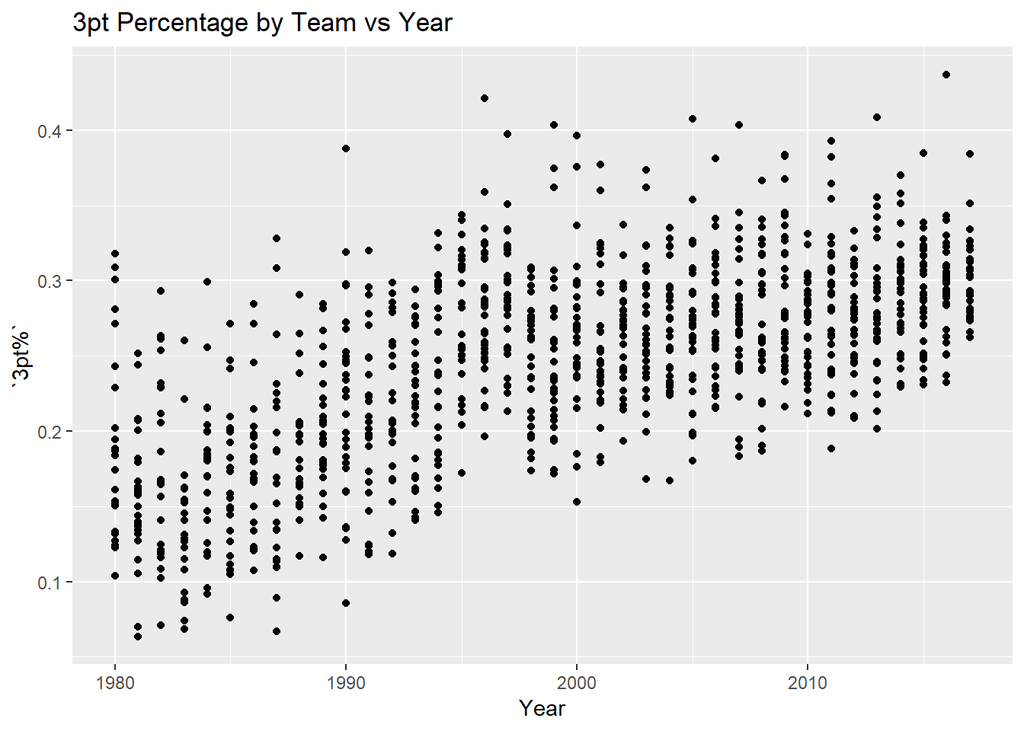

```r
teams %>%
  group_by(Team, Year) %>%
  summarize(`3pt%`=mean(`3P%`, na.rm=TRUE)) %>%
  ggplot(mapping=aes(y=`3pt%`, x=Year)) +
  ggtitle("3pt Percentage by Team vs Year") +
  geom_point()
```

Already, we can begin to see a possible correlation between Year and the 3pt percentages of the teams. We can repeat this for some other possibly interesting relationships between variables.

Although I am a Golden State Warriors fan, so I am probably a bit biased in this regard, I would consider the Warriors to be one of the major teams that has led this 3pt shooting revolution. Because of this, lets look at specifically the Warriors, which will also probably be more digestible than the previous graph. Along with this, we can begin to look graphically at the possible relationships between the variables using a regression line (or the geom_smooth function).

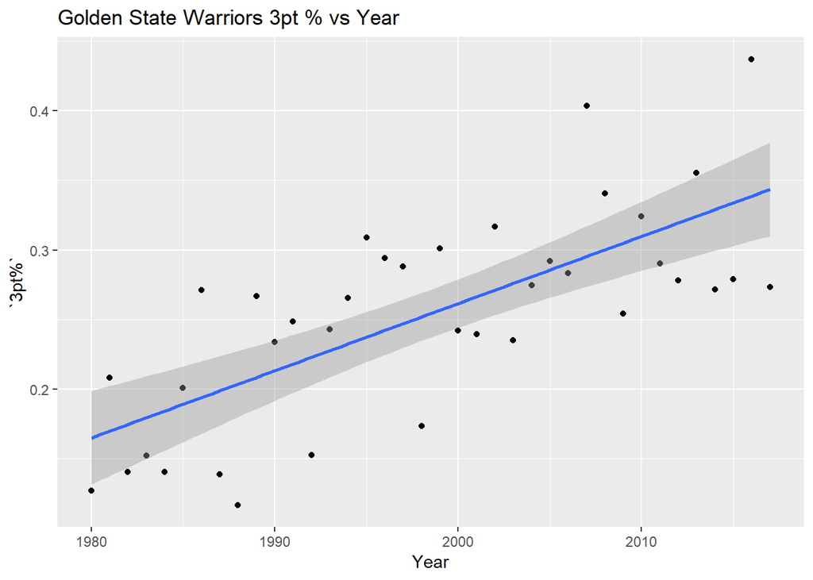

```r
teams %>%
  group_by(Team, Year) %>%
  filter(Team=='GSW') %>%
  summarize(`3pt%`=mean(`3P%`, na.rm=TRUE)) %>%
  ggplot(mapping=aes(y=`3pt%`, x=Year)) +
  geom_point() +
  geom_smooth(method=lm) +
  ggtitle("Golden State Warriors 3pt % vs Year")
```

Along with this, we can look at how the number of 3pt shots attempted has changed over time.

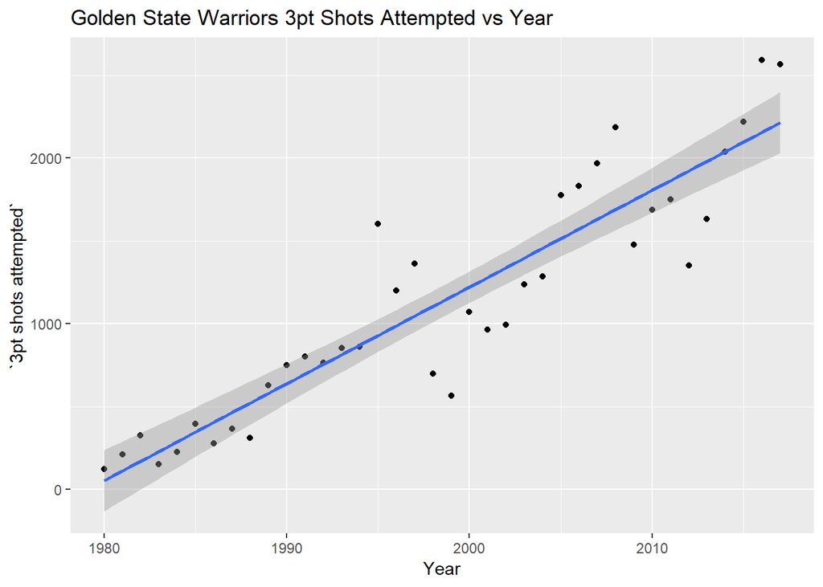

```r
teams %>%
  group_by(Team, Year) %>%
  filter(Team=='GSW') %>%
  summarize(`3pt shots attempted`=sum(`3PA`, na.rm=TRUE)) %>%
  ggplot(mapping=aes(y=`3pt shots attempted`, x=Year)) +
  geom_point() +
  geom_smooth(method=lm) +
  ggtitle("Golden State Warriors 3pt Shots Attempted vs Year")
```

As we can now see, not only are the warriors getting better at 3pt shooting (have a higher 3pt percentage), but they are also taking significantly more 3pt shots than they used to. Indicating just how integral a part of the game 3pt shooting as become.

Looking at other notable 3pt shooting teams around the league, we can see how their 3pt shooting has varied over time as well. Along with this, we can use the help of color to differentiate the teams and make the graphs easier to read.

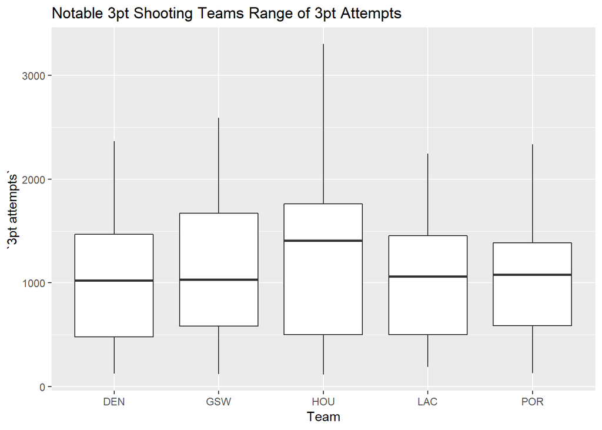

```r
# Looking at the Warriors, the Rockets, the Clippers, the Trail Blazers, and the Nuggets
notable_teams <- c('GSW', 'HOU', 'LAC', 'POR', 'DEN')
teams %>%
  group_by(Team, Year) %>%
  filter(Team %in% notable_teams) %>%
  summarize(`3pt attempts`=sum(`3PA`, na.rm=TRUE)) %>%
  ggplot() +
  geom_boxplot(mapping=aes(y=`3pt attempts`, x=Team)) +
  ggtitle("Notable 3pt Shooting Teams Range of 3pt Attempts")
```

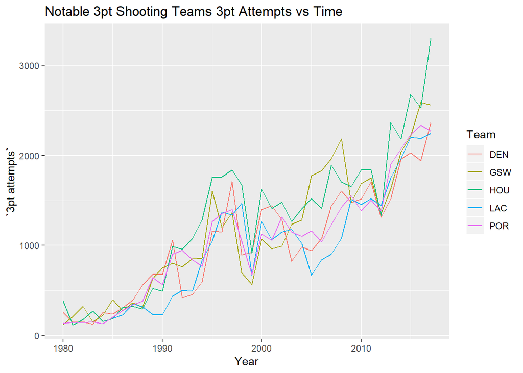

```r
teams %>%
  group_by(Team, Year) %>%
  filter(Team %in% notable_teams) %>%
  summarize(`3pt attempts`=sum(`3PA`, na.rm=TRUE)) %>%
  ggplot() +
  geom_line(mapping=aes(y=`3pt attempts`, x=Year, color=Team)) +
  ggtitle("Notable 3pt Shooting Teams 3pt Attempts vs Time")
```

## Data Transformations

It is usually very useful to think of data in the same uniform unit-less scale. Scaling the data solves this issue by transforming the data from “x” units in measurement, to “standard deviations away from the mean”. I scaled the 3pt attempts by year and compare them with the average 3pt attempts over all years. This can possible tell us that 3pt attempts used to be significantly lower because there are more years that are positive standard deviations away from the mean. This means that the years where 3pt attempts were low must have been very low, in order to lower the overall mean that much. However, this graph is still fairly difficult to read and can definitely still be improved.

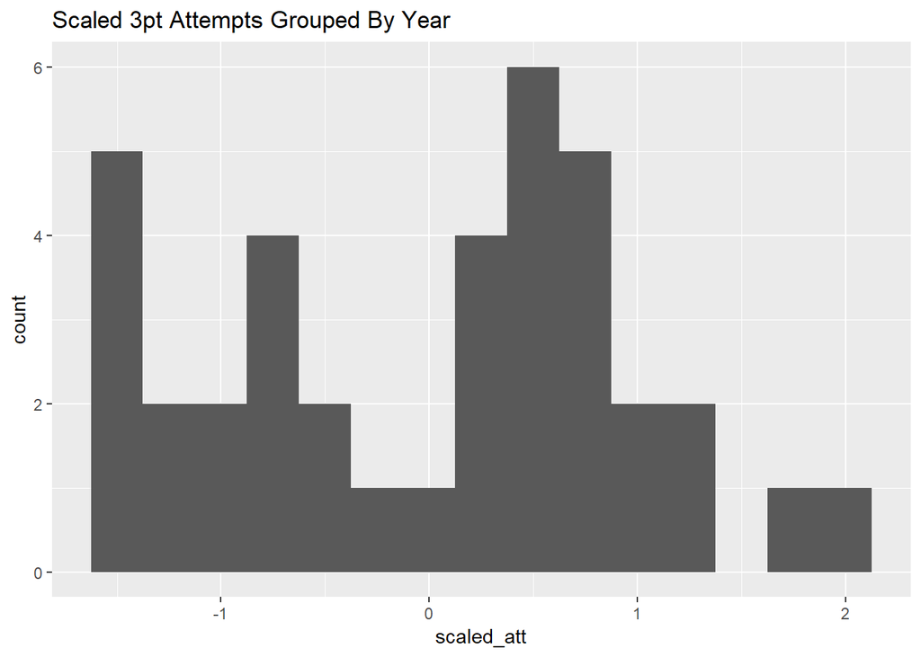

```r
teams %>%
  group_by(Year) %>%
  summarize(`3pt attempts`=mean(`3PA`, na.rm=TRUE)) %>%
  mutate(scaled_att = (`3pt attempts` - mean(`3pt attempts`)) / sd(`3pt attempts`)) %>%
  ggplot(aes(x=scaled_att)) +
  geom_histogram(binwidth=.25) +
  ggtitle("Scaled 3pt Attempts Grouped By Year")
```

This improvement can come from breaking the data into different quantiles, as we see that this leads to a much more even distribution.

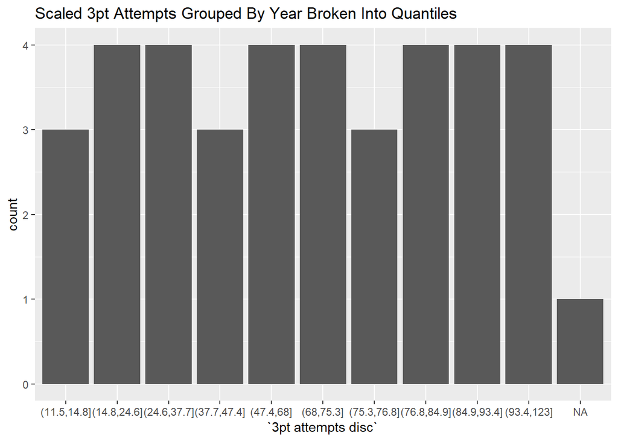

```r
teams %>%
  group_by(Year) %>%
  summarize(`3pt attempts`=mean(`3PA`, na.rm=TRUE)) %>%
  mutate(`3pt attempts disc`=cut(`3pt attempts`, breaks=quantile(`3pt attempts`, probs=seq(0,1,len=11), na.rm=TRUE))) %>%
  ggplot(aes(x=`3pt attempts disc`)) +
  geom_bar() +
  ggtitle("Scaled 3pt Attempts Grouped By Year Broken Into Quantiles")
```

## Linear regression

As seen earlier, we used a combination of the geom_smooth function and the lm method to produce a line of best fit, or linear regression. We can again fit this with the league average 3pt percentages and attempts over time.

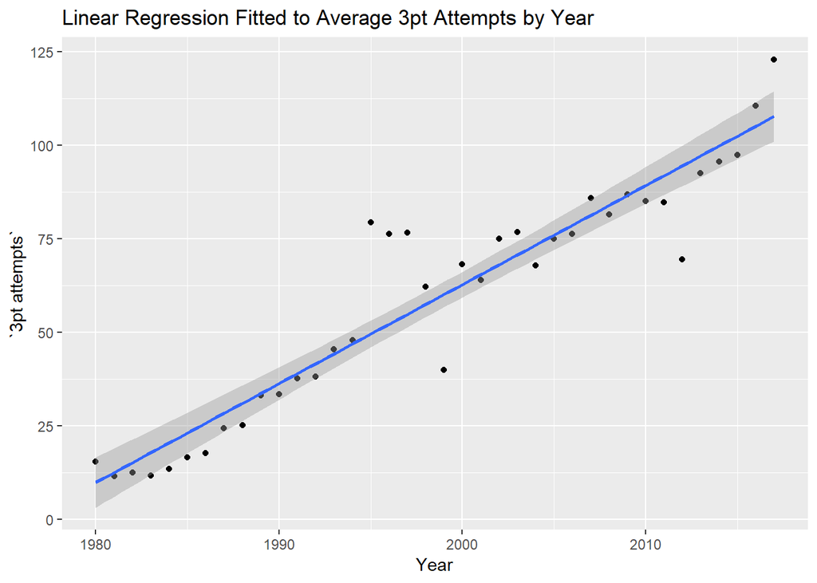

```r
teams %>%
  group_by(Year) %>%
  summarize(`3pt attempts`=mean(`3PA`, na.rm=TRUE)) %>%
  ggplot(aes(x=Year, y=`3pt attempts`)) +
  geom_point() +
  geom_smooth(method=lm) +
  ggtitle("Linear Regression Fitted to Average 3pt Attempts by Year")
```

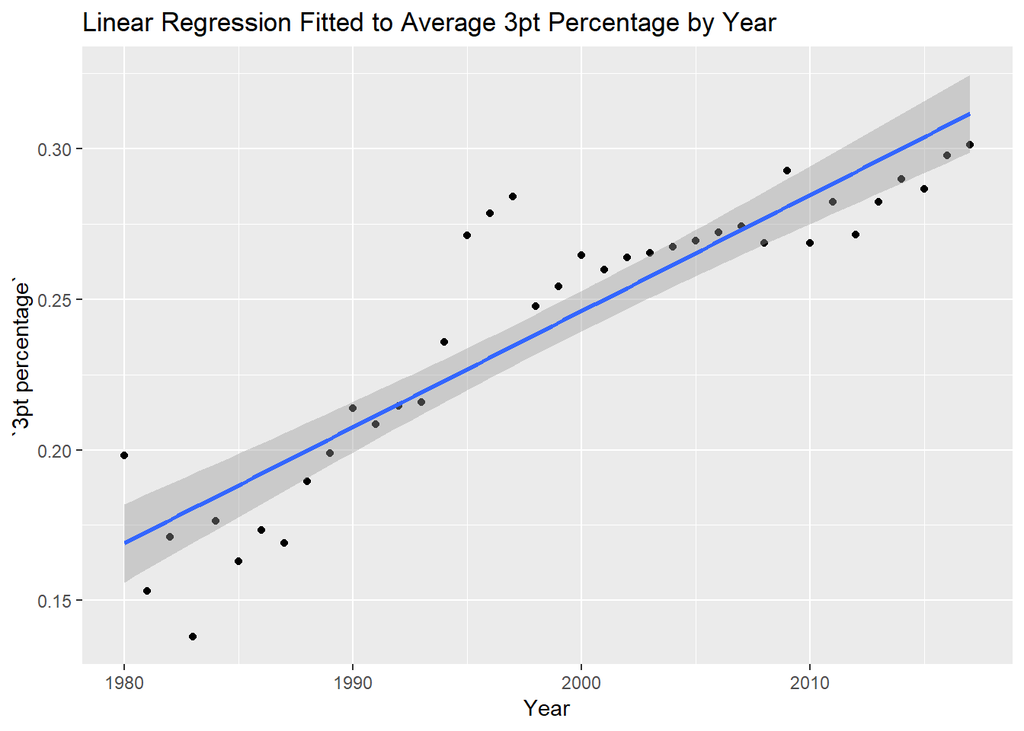

```r
teams %>%
  group_by(Year) %>%
  summarize(`3pt percentage`=mean(`3P%`, na.rm=TRUE)) %>%
  ggplot(aes(x=Year, y=`3pt percentage`)) +
  geom_point() +
  geom_smooth(method=lm) +
  ggtitle("Linear Regression Fitted to Average 3pt Percentage by Year")
```

From this, we can see the weight of the year on the 3pt percentage and attempts. That is, the coefficient in the linear model that relates the two variables.

```r
lm(`3P%`~Year, data=teams)
```

```
##
## Call:
## lm(formula = `3P%` ~ Year, data = teams)
##
## Coefficients:
## (Intercept)         Year
##   -7.068689     0.003658
```

```r
lm(`3P%`~Year, data=teams) %>%
  tidy()
```

```
## # A tibble: 2 x 5
##   term        estimate std.error statistic   p.value
##   <chr>          <dbl>     <dbl>     <dbl>     <dbl>
## 1 (Intercept) -7.07     0.259        -27.3 2.19e-160
## 2 Year         0.00366  0.000129      28.3 1.88e-171
```

## Conclusion

From the exploration conducted on our data, we can confidently say that the NBA is definitely shooting more 3-pointers and has also gotten significantly better at shooting 3-pointers as well. However, it will be interesting to see how this trend continues as NBA games are limited to 48 minutes, which I do not see changing anytime soon. It will be interesting to see if the 3 point attempts per game is reaching its peak, or will continue to increase for a while. This data set is also very extensive and could be used to answer many other interesting questions in the future. For example, it would be interesting to see the 3-point changes over time in the different positions of basketball, especially the centers or powerforwards. I would encourage the reader to download the dataset and conduct their own experiments.